# Willow Creek Anticline Data Visualization

Plotting Assignment #8, #9, and #10: Research Data Plots

Author

Haley Brumberger

Published

April 19, 2026

# 1 Setup

Using R version 4.5.2 (2025-10-31) , R Core Team (2022), and ggplot2 version 4.0.2 from the tidyverse (Wickham et al. 2019).

```r
# install packages that aren't already installed
#install.packages(c("tidyverse","ggpspatial",s"sf","stars","rnaturalearth","rnaturalearthdata","patchwork","ggstar","elevatr","terra","tidyterra","cowplot","gt"))

# load packages
library(tidyverse)
library(ggspatial)
library(sf)
library(stars)
library(rnaturalearth)
library(rnaturalearthdata)
library(patchwork)
library(ggstar)
library(elevatr)
library(terra)
library(tidyterra)
library(cowplot)
library(gt)
```

# 2 Geologic Map of Choteau, MT with Willow Creek Anticline Callout

## 2.1 Data

```r
# load line layer representing contacts and faults
choteau_contacts_faults <- read_sf(
  "data/NGMDB_GeMS_4405-2/GeMS_shapefiles/ContactsAndFaults.shp"
) |>
  st_transform("WGS84") # transform to WGS84 coordinate system

# load polygon layer representing the distribution of geologic map units
choteau_map_units <- read_sf(
  "data/NGMDB_GeMS_4405-2/GeMS_shapefiles/MapUnitPolys.shp"
) |>
  st_transform("WGS84") # transform to WGS84 coordinate system

# load description of map units table
# AreaFillRGB read as character to preserve "xxx,xxx,xxx" format (prevents conversion to scientific notation)
choteau_map_units_desc <- read_csv(
  "data/NGMDB_GeMS_4405-2/GeMS_shapefiles/DescriptionOfMapUnits.csv",
  col_types = cols(AreaFillRGB = col_character())
)

# disable spherical geometry to allow planar centroid calculations
sf_use_s2(FALSE)
```

```
Spherical geometry (s2) switched off
```

[figure not shown]

```r
# load all us states from rnaturalearth
states <- ne_states(country = "United States of America") |>
  st_as_sf() # convert to sf object

# filter to montana only
mt <- states |> filter(name == "Montana")

# load montana county boundaries from maps package
counties_mt <- maps::map("county", fill = TRUE) |>
  st_as_sf() |>
  tidyr::separate(ID, into = c("state", "county"), sep = ",") |> # split ID into state and county columns
  st_as_sf() |>
  filter(state == "montana") |> # keep only montana counties
  st_transform("WGS84") # transform to WGS84 coordinate system
```

```r
# compute montana bounding box
mt_bbox <- mt |>
  st_bbox()

# expand montana bounding box by 0.5 degrees on each side for context/to see the outline better in the map
mt_bbox_vector <- mt_bbox |> as.vector() # convert bbox to plain numeric vector to expand

mt_xmin_expanded <- mt_bbox_vector[1] - 0.5 # expand west edge
mt_ymin_expanded <- mt_bbox_vector[2] - 0.5 # expand south edge
mt_xmax_expanded <- mt_bbox_vector[3] + 0.5 # expand east edge
mt_ymax_expanded <- mt_bbox_vector[4] + 0.5 # expand north edge

mt_bbox_expanded <- st_bbox(
  c(
    xmin = mt_xmin_expanded,
    xmax = mt_xmax_expanded,
    ymin = mt_ymin_expanded,
    ymax = mt_ymax_expanded
  ),
  crs = st_crs(4326) # set CRS to WGS84
)

# calculate choteau quadrangle bounding box from map unit polygons
choteau_bbox <- choteau_map_units |> st_bbox()

# define field site coordinates for willow creek anticline
wca_coords <- tibble(
  Site = c(
    "Willow Creek Anticline Camp Site",
    "'79 Hatchling Nest Stratigraphic Section",
    "Rainbow Mountain Stratigraphic Section"
  ),
  Longitude = c(-112.41743, -112.42001, -112.426692),
  Latitude = c(47.81059, 47.81182, 47.80940)
)

# convert wca coordinates to sf and calculate bounding box
wca_bbox <- wca_coords |>
  st_as_sf(coords = c("Longitude", "Latitude"), crs = 4326) |> # convert to sf point object
  st_bbox() # calculate bounding box

# expand wca bounding box to add context around the field sites
wca_bbox_vector <- wca_bbox |> as.vector() # convert bbox to plain numeric vector to expand

wca_xmin_expanded <- wca_bbox_vector[1] - 0.007 # expand west edge
wca_ymin_expanded <- wca_bbox_vector[2] - 0.004 # expand south edge
wca_xmax_expanded <- wca_bbox_vector[3] + 0.0075 # expand east edge
wca_ymax_expanded <- wca_bbox_vector[4] + 0.005 # expand north edge

wca_bbox_expanded <- st_bbox(
  c(
    xmin = wca_xmin_expanded,
    xmax = wca_xmax_expanded,
    ymin = wca_ymin_expanded,
    ymax = wca_ymax_expanded
  ),
  crs = st_crs(4326) # set CRS to WGS84
)
```

## 2.2 Manipulating Data to Make Useful Dataframes

```r
# join color data from description table to map units using shared Label column as the 'by'
choteau_map_units_wcolor <- choteau_map_units |>
  left_join(
    choteau_map_units_desc |>
      select(-MapUnit) |> # drop duplicate MapUnit column from description table
      filter(!is.na(Label)), # remove rows with no Label value
    by = "Label" # join by Label column
  )

# convert RGB string (xxx,xxx,xxx) to hex color code for use in ggplot
choteau_map_units_wcolor <- choteau_map_units_wcolor |>
  mutate(
    hex_color = map_chr(
      # map_chr() transforms its input by applying a function to each element of a list or atomic vector and returning an object of the same length as the input.
      # applying this function to AreaFillRGB returns a character vector, and the map_chr _chr suffix enforces character output type
      AreaFillRGB, # input column containing RGB strings from tibble (e.g. "255,0,0")
      ~ {
        if (is.na(.x)) {
          return(NA_character_)
        } # if no RGB value exists, assign NA to hex_color
        vals <- as.integer(str_split(.x, ",")[[1]]) # split "xxx,xxx,xxx" by comma into vector of 3 integers
        rgb(vals[1], vals[2], vals[3], maxColorValue = 255) # convert R, G, B integers to hex code (e.g. "#FF0000") using rgb() function
      }
    )
  )

# compute polygon centroids for map unit labels
# set map projection to montana state plane (epsg 32100) for accurate area calculation
choteau_centroids <- choteau_map_units_wcolor |>
  st_transform(32100) |> # project to montana state plane
  mutate(area = st_area(geometry)) |> # calculate polygon area
  filter(area > units::set_units(50, km^2)) |> # keep only polygons larger than 50 km2
  st_point_on_surface() |> # place point guaranteed inside polygon
  st_transform(st_crs(choteau_map_units_wcolor)) # transform back to original crs
# extract unique label-color pairs as a named vector for scale_fill_manual
polygon_colors <- choteau_map_units_wcolor |>
  st_drop_geometry() |> # remove geometry column to work with the data as a plain dataframe
  filter(!is.na(hex_color)) |> # remove map units that have no associated color
  distinct(Label, hex_color) |> # keep only unique label-color pairs (one row per map unit)
  deframe() # convert two-column dataframe to named character vector where Label becomes the name and hex_color becomes the value e.g. c("Kbf" = "#FF0000", "Jn" = "#00FF00"), the required format for scale_fill_manual(values = )

# define colors for each field site star marker
star_colors <- c(
  "Willow Creek Anticline Camp Site" = "red", # camp site in red
  "'79 Hatchling Nest Stratigraphic Section" = "yellow", # 1979 hatchling nest in yellow
  "Rainbow Mountain Stratigraphic Section" = "blue" # rainbow mountain section in blue
)

# download elevation raster for the choteau area at zoom level 7 to not overload the map/crash R
choteau_elev <- get_elev_raster(
  locations = choteau_map_units_wcolor, # use map units extent to define download area
  z = 7 # zoom level 7 (coarser resolution, faster download)
) |>
  rast() # convert to terra SpatRaster format (spatially referenced surface divided into 3D cells: rows, columns, and layers) so I can plot using geom_spatraster_contour()
```

```
Mosaicing & Projecting
```

```
Note: Elevation units are in meters.
```

```r
# load choteau elevation contour from the National Elevation Dataset at higher resolution for WCA field site plot (unsure how to cite^)
WCA_elev_contour <- read_sf(
  "data/VECTOR_Watson_Flats_MT_7_5_Min_Shape/Shape/Elev_Contour.shp"
) |>
  st_transform("WGS84") # transform to WGS84 coordinate system

# test elevation contour map
# ggplot() +
#   geom_sf(data = choteau_elev_contour, aes(color = ContourEle), linewidth = 0.1)
```

## 2.3 Maps and Geologic Maps

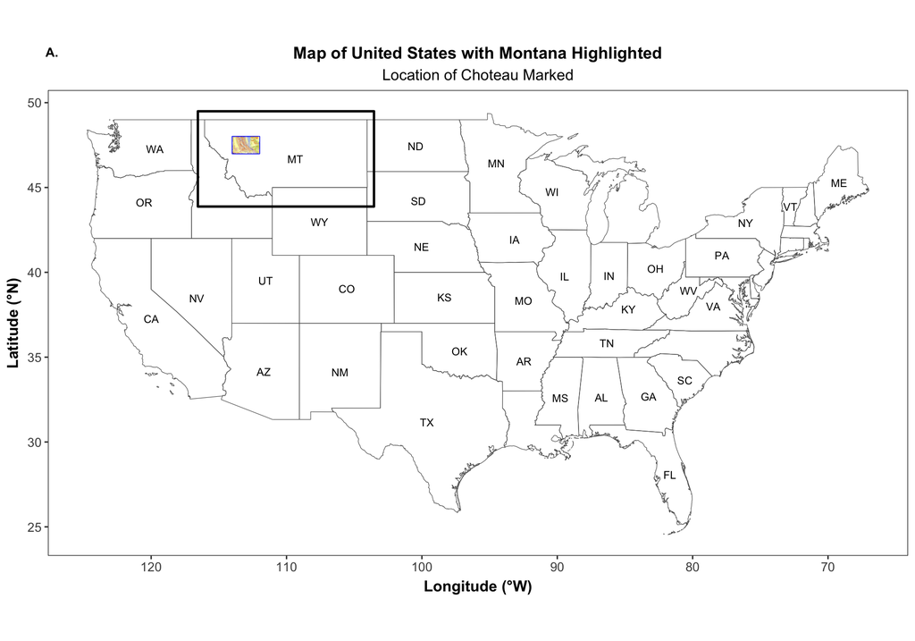

```r
# custom theme based on theme_bw
my_theme <- theme_bw() +
  theme(
    panel.grid = element_blank(), # remove grid lines
    plot.title = element_text(
      size = 13,
      hjust = 0.5, # center title
      face = "bold"
    ),
    plot.subtitle = element_text(size = 12, hjust = 0.5), # center subtitle
    axis.title = element_text(size = 12, hjust = 0.5, face = "bold"), # bold and center axis titles
    axis.title.y = element_text(margin = margin(r = 5)), # add small margin to y axis title
    axis.title.x = element_text(margin = margin(t = 5)),
    axis.text = element_text(size = 10), # add small margin to x axis title
    plot.tag = element_text(size = 10, face = "bold") # bold plot tags
  )


# plot 1: map of contiguous united states with montana and choteau highlighted
plot1 <- ggplot() +
  geom_sf(
    data = states |> filter(name != "Hawaii", name != "Alaska"), # filter out non-contiguous states
    fill = NA # transparent fill
  ) +
  geom_sf_text(
    data = states |>
      filter(
        # filter out states with no room for labels
        name != "Hawaii",
        name != "Alaska",
        name != "Rhode Island",
        name != "Massachusetts",
        name != "Connecticut",
        name != "Maryland",
        name != "District of Columbia",
        name != "New Jersey",
        name != "Delaware",
        name != "Louisiana",
        name != "Idaho",
        name != "New Hampshire",
        name != "North Carolina",
        name != "Michigan"
      ),
    aes(label = postal), # label states with postal codes
    size = 3
  ) +
  geom_sf(
    data = mt_bbox_expanded |> st_as_sfc(), # convert montana bbox to sfc for plotting
    color = "black",
    linewidth = 0.9,
    fill = NA # transparent fill
  ) +
  geom_sf(data = choteau_bbox |> st_as_sfc(), color = "blue", linewidth = 0.5) + # choteau bbox in red
  geom_sf(data = choteau_map_units_wcolor, aes(fill = hex_color), color = NA) + # geologic map units
  scale_fill_identity() + # use hex codes directly as fill colors
  labs(
    title = "Map of United States with Montana Highlighted",
    subtitle = "Location of Choteau Marked",
    x = "Longitude (°W)",
    y = "Latitude (°N)",
    tag = "A." # plot tag for composite
  ) +
  scale_x_continuous(labels = function(x) paste0(abs(x))) +
  scale_y_continuous(labels = function(y) paste0(abs(y))) + # remove degrees signs since they're in the axes titles and they make the labels too long
  guides(y = guide_axis(minor.ticks = TRUE)) +
  my_theme +
  theme(
    plot.tag.position = c(0.05, 0.99) # position tag top left
  )

plot1
```

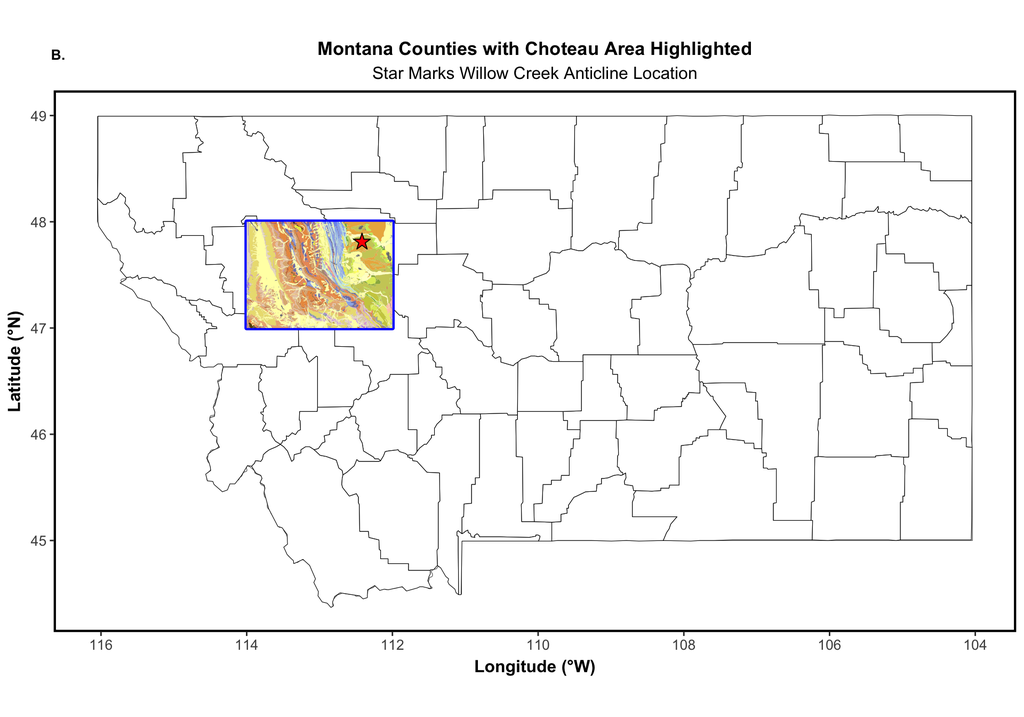

```r
# plot 2: map of montana with choteau area and willow creek anticline highlighted
plot2 <- ggplot() +
  geom_sf(data = mt, fill = NA) + # montana state boundary
  geom_sf(
    data = counties_mt, # montana county boundaries
    aes(geometry = geom),
    color = "black", # black outline
    fill = "white", # white fill
  ) +
  geom_sf(data = choteau_bbox |> st_as_sfc(), color = "blue", linewidth = 1.5) + # choteau bbox in red
  geom_sf(
    data = choteau_map_units_wcolor,
    aes(fill = Label), # fill by geologic unit label
    color = NA,
    show.legend = FALSE # hide legend
  ) +
  geom_star(
    data = wca_coords |> filter(Site == "Willow Creek Anticline Camp Site"), # filter to camp site only
    aes(x = Longitude, y = Latitude),
    size = 3.5,
    fill = "red",
    show.legend = FALSE
  ) +
  scale_fill_manual(values = c(polygon_colors)) + # use initialized polygon colors
  labs(
    title = "Montana Counties with Choteau Area Highlighted",
    subtitle = "Star Marks Willow Creek Anticline Location",
    x = "Longitude (°W)",
    y = "Latitude (°N)",
    tag = "B."
  ) +
  scale_x_continuous(labels = function(x) paste0(abs(x))) +
  scale_y_continuous(labels = function(y) paste0(abs(y))) + # remove degrees signs since they're in the axes titles and they make the labels too long
  my_theme +
  theme(
    panel.border = element_rect(color = "black", linewidth = 1.5), # black border around plot
    plot.tag.position = c(0.05, 0.98) # set position of "A." tag to top left
  )

plot2
```

```r
# plot 3 with topography: choteau quadrangle geologic map with contour lines
plot3_with_topo <- ggplot() +
  geom_sf(
    data = choteau_map_units_wcolor,
    aes(fill = Label), # fill polygons by geologic unit
    color = NA,
    show.legend = FALSE
  ) +
  geom_sf_text(
    data = choteau_centroids, # label centroids with map unit codes
    aes(label = MapUnit), # use the MapUnit column to label the lithologies
    size = 3,
    color = "black",
    fontface = "bold"
  ) +
  geom_sf(data = choteau_contacts_faults, linewidth = 0.1) + # geologic contacts and faults
  scale_fill_manual(values = polygon_colors) + # use initialized polygon colors from df above
  geom_spatraster_contour(
    data = choteau_elev, # elevation raster for contour lines
    breaks = seq(1000, 3000, by = 200), # contour interval every 200m
    color = "black",
    linewidth = 0.1,
    alpha = 0.4 # semi-transparent contours
  ) +
  geom_star(
    data = wca_coords |> filter(Site == "Willow Creek Anticline Camp Site"), # use only WCA camp site for star location
    aes(x = Longitude, y = Latitude),
    fill = "red",
    size = 7,
    show.legend = FALSE
  ) +
  annotation_scale(location = "bl", unit_category = "metric", text_cex = 1) + # add scale bar to bottom left in metric units
  annotation_north_arrow(
    # add north arrow to top left of plot and set the height, width, and style (with N letter text size)
    location = "tl",
    height = unit(0.075, "npc"), # set height and width relative to size of plot
    width = unit(0.05, "npc"), # npc is percent of the coordinate system
    style = north_arrow_orienteering(text_size = 10)
  ) +
  coord_sf(
    # use/crop to the bounding box made above
    xlim = c(choteau_bbox$xmin + 0.08, choteau_bbox$xmax - 0.08), # trim edges slightly
    ylim = c(choteau_bbox$ymin + 0.038, choteau_bbox$ymax - 0.038),
    clip = "on" # clip edges so it's exactly the defined extent
  ) +
  labs(
    # set labels/titles/tag
    title = "Choteau Quadrangle Geologic Map with Topography",
    subtitle = "Willow Creek Anticline Field Site Location Marked",
    x = "Longitude (°W)",
    y = "Latitude (°N)",
    tag = "C."
  ) +
  scale_x_continuous(labels = function(x) paste0(abs(x))) +
  scale_y_continuous(labels = function(y) paste0(abs(y))) + # remove degrees signs since they're in the axes titles and they make the labels too long
  my_theme +
  theme(
    panel.border = element_rect(color = "blue", linewidth = 1), # blue border for emphasis/connection to previous plot
    plot.tag.position = c(0.05, 0.98) # set plot tag location
  )
```

```
<SpatRaster> resampled to 500488 cells.
```

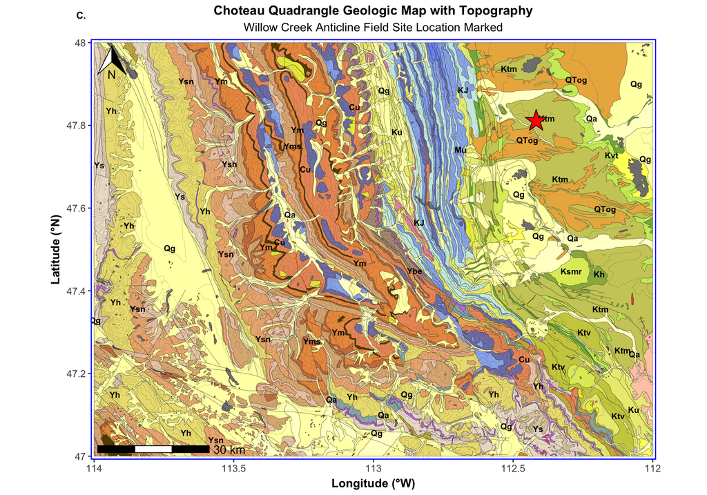

```r
plot3_with_topo
```

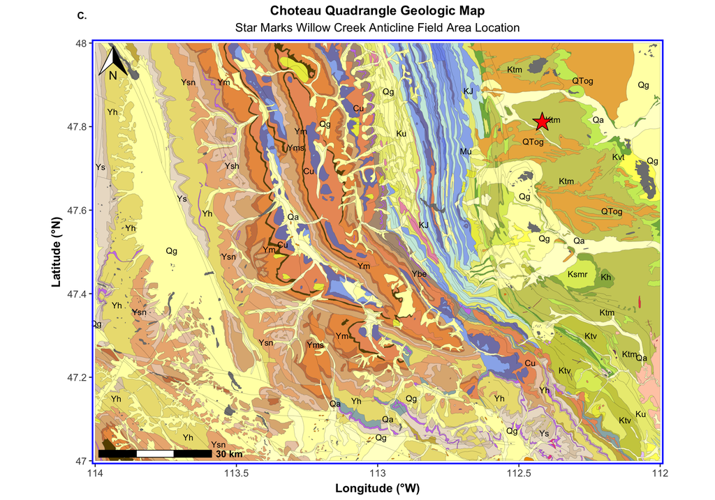

```r
# plot 3 for composite: simplified choteau map without topography for composite layout
plot3_for_composite <- ggplot() +
  geom_sf(
    data = choteau_map_units_wcolor,
    aes(fill = Label),
    color = NA,
    show.legend = FALSE
  ) +
  geom_sf_text(
    data = choteau_centroids,
    aes(label = MapUnit),
    size = 3, # smaller text for composite layout
    color = "black"
  ) +
  geom_sf(data = choteau_contacts_faults, linewidth = 0.05) + # thinner lines for composite
  geom_star(
    data = wca_coords |> # set df
      filter(Site == "Willow Creek Anticline Camp Site"), # filter to just the camp site so it's only 1 star
    aes(x = Longitude, y = Latitude), # add coordinates from the df
    fill = "red", # red fill
    size = 6, # size of star
    show.legend = FALSE # remove from legend (so there is no legend)
  ) +
  scale_fill_manual(values = polygon_colors) + # set the colors to be from the df I made with HEX color codes for each type of lithology
  annotation_scale(
    # add scale bar
    location = "bl", # bottom left
    unit_category = "metric", # metric units
    text_face = "bold",
    text_cex = 0.8 # bold scale number text
  ) +
  annotation_north_arrow(
    # add north arrow
    location = "tl", # top left
    height = unit(0.075, "npc"), # set height and width relative to size of plot
    width = unit(0.05, "npc"),
    style = north_arrow_orienteering(text_size = 10)
  ) +
  coord_sf(
    xlim = c(choteau_bbox$xmin + 0.08, choteau_bbox$xmax - 0.08),
    ylim = c(choteau_bbox$ymin + 0.038, choteau_bbox$ymax - 0.038),
    clip = "on"
  ) +
  labs(
    title = "Choteau Quadrangle Geologic Map",
    subtitle = "Star Marks Willow Creek Anticline Field Area Location",
    x = "Longitude (°W)",
    y = "Latitude (°N)",
    tag = "C."
  ) +
  scale_x_continuous(labels = function(x) paste0(abs(x))) +
  scale_y_continuous(labels = function(y) paste0(abs(y))) + # remove degrees signs since they're in the axes titles and they make the labels too long
  my_theme +
  theme(
    panel.border = element_rect(color = "blue", linewidth = 1.5),
    plot.tag.position = c(0.05, 0.98)
  )

plot3_for_composite
```

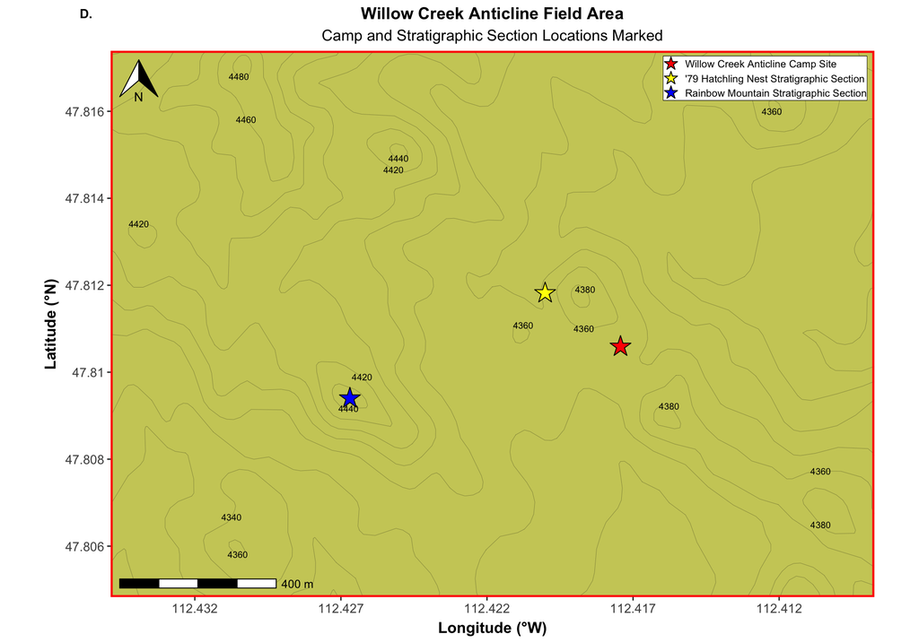

```r
# plot 4: zoomed in map of willow creek anticline field area with all site locations and topo lines
plot4 <- ggplot() + # make new plot4
  geom_sf(
    # add color for the lithology
    data = choteau_map_units_wcolor,
    aes(fill = Label),
    color = NA,
    show.legend = FALSE
  ) +
  geom_sf(
    # add contact and fault lines
    data = choteau_contacts_faults,
    linewidth = 0.05
  ) + # thinner lines for composite
  geom_sf(
    # add contour/elevation lines
    data = WCA_elev_contour,
    color = "black",
    linewidth = 0.1,
    alpha = 0.5
  ) +
  geom_sf_text(
    # add contour/elevation labels
    data = WCA_elev_contour,
    aes(label = ContourEle),
    size = 2.5 # make text small for composite plot
  ) +
  geom_star(
    data = wca_coords, # all wca site coordinates
    aes(x = Longitude, y = Latitude, fill = Site), # fill by site name
    size = 5,
    color = "black",
    starstroke = 0.5 # thinner star outline
  ) +
  scale_fill_manual(
    values = c(polygon_colors, star_colors), # combine polygon and star colors
    breaks = names(star_colors), # only show star sites in legend
    name = "Site" # set name for legend
  ) +
  annotation_scale(location = "bl", unit_category = "metric", text_cex = 0.75) +
  annotation_north_arrow(
    location = "tl",
    height = unit(0.075, "npc"),
    width = unit(0.05, "npc"),
    style = north_arrow_orienteering(text_size = 8)
  ) + #
  coord_sf(
    # zoom to wca extent
    xlim = c(wca_bbox_expanded$xmin, wca_bbox_expanded$xmax),
    ylim = c(wca_bbox_expanded$ymin, wca_bbox_expanded$ymax),
    clip = "on"
  ) +
  labs(
    # add title, subtitle, fill label for legend, and tag
    title = "Willow Creek Anticline Field Area",
    subtitle = "Camp and Stratigraphic Section Locations Marked",
    fill = "Site",
    tag = "D.",
    x = "Longitude (°W)",
    y = "Latitude (°N)"
  ) +
  scale_x_continuous(
    breaks = seq(-112.432, -112.412, 0.005), # set axis breaks/labels to show better the coordinates
    labels = function(x) paste0(abs(x))
  ) +
  scale_y_continuous(labels = function(y) paste0(abs(y))) + # remove degrees signs since they're in the axes titles and they make the labels too long
  my_theme +
  guides(
    fill = guide_legend(
      override.aes = list(size = 3) # adjust until it looks right
    )
  ) +
  theme(
    legend.position = "inside", # place legend inside plot
    legend.justification = c("right", "top"), # right justify legend
    legend.position.inside = c(.99, .99), # set position relative to top right
    legend.box.just = "right", # right justify legend boxes
    legend.box.background = element_rect(
      color = "black",
      fill = "white",
      linewidth = 0.2 # thin black border around legend box
    ),
    legend.box.margin = margin(0.2, 0.2, 0.2, 0.2), # margin around legend box
    legend.margin = margin(0.2, 0.2, 0.2, 0.2), # margin inside legend box
    legend.key.size = unit(0.4, "cm"), # spacing between legend keys
    legend.key = element_blank(), # get rid of grey background for the star icons
    legend.title = element_blank(), #get rid of legend title since stars are self-explanatory (and mentioned in subtitle)
    # legend.title = element_text(
    #   hjust = 0.5,
    #   size = 9,
    #   face = "bold",
    #   margin = margin(b = 1.5)
    # ), # centered bold legend title, set bottom margin to be smaller
    legend.text = element_text(size = 8), # small legend text
    plot.tag.position = c(0.05, 0.99), # set tag location
    panel.border = element_rect(color = "red", linewidth = 1.5) # add red plot border
  )

plot4
```

## 2.4 Composite Plots 1-4

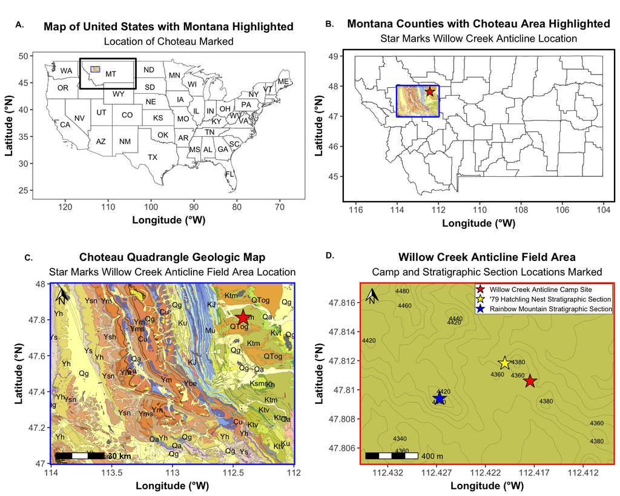

Figure 1: This figure is a composite plot of 4 maps that zoom in progressively, showing A) the location of Montana in the US, and Choteau in Montana; B) the location of Choteau and the Willow Creek Anticline (marked with a red star) in Montana; C) the location of the Willow Creek Anticline within the Choteau quadrangle geologic map (marked with a red star again); and D) the coordinates of 3 locations of interest at the Willow Creek Anticline: the camp site, the ’79 Hatchling Nest Stratigraphic Section, and the Rainbow Mountain Stratigraphic Section.

```r
# looks weird in plot viewer but renders OK
composite_plot <- ggdraw() + # add all plots with x and y coordinates (relative) so they all fit, 2 next to each other/stacked (2 rows + 2 columns)
  draw_plot(plot1, x = 0, y = 0.5, width = 0.5, height = 0.5) +
  draw_plot(plot2, x = 0.5, y = 0.5, width = 0.5, height = 0.5) +
  draw_plot(plot3_for_composite, x = 0, y = 0, width = 0.5, height = 0.5) +
  draw_plot(plot4, x = 0.5, y = 0, width = 0.5, height = 0.5)
composite_plot # plot composite plot
```

## 2.5 Failed Composite Plot

```r
## below code does not work in html rendering, makes the margins between plots huge
# composite_plot <- ((plot1 + plot2) &
#   theme(plot.margin = margin(0, 0, 0, 0, "pt"))) /
#   ((plot3_for_composite + plot4) +
#     plot_layout(widths = 1.75, heights = 1) &
#     theme(plot.margin = margin(0, 0, 0, 0, "pt")))

# composite_plot <- composite_plot &
#   labs(x = NULL, y = NULL) &
#   theme(plot.title = element_blank())

# composite_plot <- composite_plot +
#   plot_annotation(
#     title = "Maps of United States, Montana,\nChoteau, and Willow Creek Anticline Field Area",
#     tag_levels = "A",
#     theme = theme(
#       plot.title = element_text(
#         hjust = 0.5,
#         size = 12,
#         face = "bold",
#         margin = margin(b = 0, unit = "pt")
#       ),
#       plot.background = element_rect(
#         color = "black",
#         linewidth = 1.5,
#         fill = NA
#       )
#     )
#   )

# composite_plot <- composite_plot &
#   theme(plot.tag.position = c(0.15, 1.01))
# composite_plot

# # labeled_plot <- ggdraw(composite_plot) +
# #   draw_label(
# #     "Longitude",
# #     x = 0.5,
# #     y = 0.02,
# #     hjust = 0.5,
# #     size = 11,
# #     fontface = "bold"
# #   ) +
# #   draw_label(
# #     "Latitude",
# #     x = 0.01,
# #     y = 0.5,
# #     hjust = 0.5,
# #     size = 11,
# #     fontface = "bold",
# #     angle = 90
# #   )

# # labeled_plot
```

# 3 Table with Different Lithologies

```r
# This chunk partially from Claude (AI) because I didn't know how to make tables but I thought it would be useful to have a table/legend for the lithologies of Choteau area that I plot above (even though the WCA is only one kind of lithology--Upper Cretaceous Two Medicine Fm)

legend_table <- choteau_map_units_wcolor |>
  st_drop_geometry() |> # remove geometry column
  distinct(MapUnit, Name, Age, Description, hex_color) |> # keep only unique rows
  filter(!is.na(hex_color)) |> # remove rows without color
  arrange(Age) |> # sort by age
  mutate(Color = "") |> # add empty column for color swatches
  gt() |> # convert to gt table (like ggplot for tables)
  tab_header(title = "Geologic Map Units") |> # add table title
  tab_style(
    style = cell_fill(color = from_column("hex_color")), # fill color swatch with hex color
    locations = cells_body(columns = Color) # apply to Color column only
  ) |>
  cols_hide(hex_color) |> # hide hex code column from display
  cols_move_to_start(columns = Color) |> # move color swatch to first column
  cols_label(
    # rename column headers
    Color = "Color",
    MapUnit = "Unit",
    Name = "Name",
    Age = "Age",
    Description = "Description"
  ) |>
  tab_style(
    style = cell_text(size = px(10)), # set column header text size
    locations = cells_column_labels()
  ) |>
  tab_style(
    style = cell_text(size = px(9)), # set body text size
    locations = cells_body()
  ) |>
  tab_style(
    style = cell_text(size = px(11)), # set title text size
    locations = cells_title()
  ) |>
  tab_style(
    style = cell_borders(
      sides = c("left", "top"), # add left and top borders
      color = "black",
      weight = px(0.5) # border thickness
    ),
    locations = cells_body() # apply to all body cells
  )

legend_table # make the table
```

Table 1: Table showing all lithology units for the Choteau Quadrangle geologic map (Figure 1C).

Geologic Map Units

| Color | Unit | Name | Age | Description |
| --- | --- | --- | --- | --- |
|  | Cu | Cambrian rocks undivided | Cambrian | Complete sections of these rocks are only in the western outcrop. Deiss (1939 - DAS23) divided these rocks into nine formations: Devils Glen Dolomite (top), Switchback Shale, Steamboat Limestone, Pent… |
|  | Kl | Latite | Cretaceous | Sill, gray, grayish-purple; massive and porphyritic with abundant phenocrysts of labradorite in an aphanitic groundmass (Schmidt, 1972c - DAS17, 1978 - DAS31). Present only in southeast corner of map … |
|  | Ku | Upper and Lower Cretaceous rocks undivided | Cretaceous | Upper and lower cretaceous rocks undivided, includes Two Medicine Formation, Virgelle Sandstone, Telegraph Creek Formation, Marias River Shale, and Blackleaf, Kootenai, and Mount Pablo Formations |
|  | Tm | Hornblende monzonite | Eocene? | Light-gray, fine-grained, equigranular dikes and sills composed of andesine, sanidine, hornblende, augite, biotite, magnetite, and apatite. Hornblende needles, 3-4 mm long, characterize the rock (Schm… |
|  | Tmp | Monzonite porphyry | Eocene? | Stocks, dikes, and sills, of light-gray, abundant, 1-cm and larger phenocrysts of orthoclase that weather out as euhedral crystals. Dated at 58.3 m.y. by the K-Ar method (Mehnert and Schmidt, 1971 - D… |
|  | Qa | Alluvial and colluvial deposits | Holocene and Pleistocene | Unconsolidated stream-laid sand, gravel, and silt, bouldery, poorly to moderately well sorted. Includes alluvial fan, slope wash, colluvial and glacial outwash deposits of Bull Lake and younger in age… |
|  | Qg | Glacial deposits | Holocene and Pleistocene | Drift, heterogeneous mixture of rock fragments in silty clay matrix. Forms hummocky topography. Includes deposits from alpine and continental glaciations; as much as 100 m thick except in Swan River v… |
|  | Qs | Landslide deposits | Holocene and Pleistocene | Mostly rock debris, locally coarse angular rock fragments in silt or clay matrix. Forms hummocky topography. Produced by rockfall- and rockslide-avalanches, slump, and earthflow. Thickness possibly as… |
|  | KJ | Lower Cretaceous and Jurassic rocks undivided | Lower Cretaceous and Jurassic | Lower Cretaceous and Jurassic rocks undivided |
|  | Tla | Lake deposits | Miocene and Oligocene | Gray, yellowish-gray, gray-brown, sandy silt, silt, clay, shale, marl, and some poorly sorted conglomerate; locally thin coal and carbonates. Locally includes wood and leaf fragments, insects, fish, g… |
|  | Td | Dacite | Miocene? And Oligocene | Volcanic neck or plug and sills, gray to light-gray, aphanitic groundmass of greenish-gray feldspar with phenocrysts of light-gray feldspar, hornblende, and biotite. Present only at and near Haystack … |
|  | Mu | Upper and Lower Mississippian rocks undivided | Mississippian | Mississippian rocks are the main cliff former in the eastern part of the mountains and are assigned to the Madison Group. The total thickness of the Mississippian rocks ranges from 275 m to 520 m. The… |
|  | TKi | Trachyandesite | Paleocene or Upper Cretaceous | Sills, dark grayish brown, aphanitic groundmass of feldspar with phenocrysts of plagioclase, potassium feldspar, pyroxene, and quartz (Mudge, 1972 - DAS09). Widespread near the North Fork Sun River |
|  | TKp | Quartz monzonite porphyry | Paleocene or Upper Cretaceous | Sills, light-grayish-orange; coarsely porphyritic with abundant 1 cm and larger phenocrysts of potassium feldspar and oligoclase-andesine in a fine-grained groundmass (Schmidt, 1972c - DAS17, 1978 - D… |
|  | TKr | Rhyolite | Paleocene or Upper Cretaceous | Dikes and sills, light-gray to white; finely porphyritic with abundant 2-3 mm phenocrysts of quartz and oligoclase (Schmidt, 1972c - DAS17, 1978 - DAS31). Present only in southeast corner of the map a… |
|  | Ta | Biotite trachyandesite and andesite | Paleocene? | Dikes, sills, and irregular-shaped bodies. Includes trachybasalt and biotite trachybasalt of Schmidt (1972b, c - DAS16, DAS17; 1978 - DAS31). Dark-gray, aphanitic groundmass with hornblende and some b… |
|  | Tva | Adel Mountain Volcanics of Lyons (1944 - DAS25) | Paleocene? | Volcanic and volcanic-sedimentary rocks. Trachyandesite and trachybasalt flows (Schmidt, 1972a - DAS15), volcanic conglomerate, breccia, and lacustrine deposits of volcanic sandstone, siltstone, and m… |
|  | Pz | Paleozoic rocks. Includes part or all of Mississippian, Devonian, and Cambrian sequences | Paleozoic | Paleozoic rocks. Includes part or all of Mississippian, Devonian, and Cambrian sequences |
|  | Ql | Lake deposits | Pleistocene | Light-gray to dark-gray and gray-brown, thin- to thick-bedded silty clay, clay, and some sand; deposited in glacial lakes. Thickness of deposits as much as 30 m |
|  | QTog | Older gravel | Pleistocene and Possibly Pliocene | Coarse stream-laid gravel on remnants of at least four bench surfaces as much as 250 m above modern stream alluvium. Maximum thickness Is about 10 m |
|  | Tb | Basalt | Pliocene? | Occurs mostly as dark-gray to gray-brown, finely porphyritic flows with numerous calcite- and zeolite-filled cavities. Locally weathers into spheroidal boulders and overlies Tertiary lakebed deposits.… |
|  | Yb | Bonner Quartzite | Proterozoic Y | Consists mostly of pink, pale-red, and pinkish-gray, fine- to medium-grained, poorly sorted beds of quartzite that range in thickness from 31 cm to 76 cm. The quartzite is mostly feldspathic and local… |
|  | Ybe | McNamara Formation, Bonner Quartzite, and Mount Shields, Shepard, Snowslip, Helena, Empire, and Spokane Formations | Proterozoic Y | McNamara Formation, Bonner Quartzite, and Mount Shields, Shepard, Snowslip, Helena, Empire, and Spokane Formations |
|  | Ydi | Andesite, basaltic andesite, and dacite | Proterozoic Y | Thin sills, grayish-green; amphibole, biotite, and feldspar phenocrysts in aphanitic groundmass of plagioclase and ferromagnesian minerals. Probably equivalent in age (1,075 m.y.) to the Purcell Lava … |
|  | Ye | Empire Formation | Proterozoic Y | A transitional unit between the Helena and Spokane Formations. Mostly greenish gray argillite and siltite with interbeds of quartzite, dolomite, and locally stromatolitic and oolitic carbonate rock. T… |
|  | Yes | Spokane and Empire Formations undivided | Proterozoic Y | Undivided only in the eastern and part of the southern outcrop area. In those areas the unit is pale-red, maroon, green, and gray siliceous argillite and siltite, with minor thin beds of poorly sorted… |
|  | Yg | Greyson Formation | Proterozoic Y | The oldest unit exposed in and near the map area; therefore, its base is not exposed. Consists of light-gray to greenish-gray, thinly bedded siltite with some quartzite, grading down into dark-gray, g… |
|  | Ygr | Garnet Range Formation | Proterozoic Y | Consists of pale-olive to medium-gray and moderate brown, poorly sorted, very fine to fine-grained, micaceous, thin even beds of sandstone and siltstone. Locally they are speckled by hematite, crossbe… |
|  | Yh | Helena Formation | Proterozoic Y | In most places the Helena is divisible into three units. The upper unit consists of beds of limestone interbedded with dolomite, siltite, and argillite. Beds of stromatolites, oolites, and edgewise co… |
|  | Ym | McNamara Formation | Proterozoic Y | In the central and southern parts of the area the McNamara is divisible into two unnamed members, an upper dominantly reddish brown quartzite and a lower dominantly grayish green siltite (Somers, 1966… |
|  | Ymi | Bonner Quartzite and Mount Shields, Shepard, and Snowslip Formations, undivided | Proterozoic Y | Mapped only in the upper reaches of Smith and Elk Creeks |
|  | Yms | Mount Shields Formation | Proterozoic Y | Mostly bright reddish brown, thinly laminated, micaceous siltite, argillite, and thin- to thick-bedded quartzite. Sedimentary features include minute cross-laminations, ripple marks, mud-crack filling… |
|  | Ys | Spokane Formation | Proterozoic Y | Mostly pale-purplish-red and grayish-red siltite and argillite interbedded with lithologically similar greenish-gray beds. The southeastern and northwestern outcrops contain light-gray, very fine to m… |
|  | Ysh | Shepard Formation | Proterozoic Y | Consists mostly of greenish-gray to grayish-yellow micaceous siltite and some silty limestone and argillite. Beds of maroon siltite and argillite widespread in the middle part and locally in the upper… |
|  | Ysn | Snowslip Formation | Proterozoic Y | Consists of pale-red to reddish-brown beds and interbedded greenish-gray beds of argillite and siltite with some thin beds of very fine to fine-grained quartzite. Thin beds of stromatolitic and ooliti… |
|  | Zd | Diorite sills and local dikes | Proterozoic Z | Mostly diorite and quartz diorite, locally minor diorite-gabbro and monzonite. Dark gray, weathers grayish brown. Dated at 750+/-25 m.y. by K-Ar method (J. D. Obradovich, oral commun., 1966). Widespre… |
|  | Kh | Horsethief Sandstone and Bearpaw-Horsethief transition unit | Upper Cretaceous | Horsethief Sandstone is mostly gray to gray-brown, fine- to medium-grained crossbedded sandstone. The upper 6-12 m of the formation commonly contain lentils of titaniferous magnetite sandstone. Southe… |
|  | Km | Marias River Shale | Upper Cretaceous | Mostly a dark-gray mudstone that is divided into four members (listed in descending order), the Kevin, Ferdig, Cone, and Floweree, by Cobban, Erdmann, Lemke, and Maughan (1959 - DAS20, DAS21, 1976 - D… |
|  | Ksmr | St. Mary River Formation | Upper Cretaceous | Map unit includes the Paleocene and Upper Cretaceous Willow Creek Formation (Viele, 1960 - DAS14; Schmidt, 1972b - DAS16) in southeast corner of map where only the lower part of the Willow Creek is pr… |
|  | Ktm | Two Medicine Formation | Upper Cretaceous | Gray-green and gray mudstone with minor sandstone in upper and middle parts with gray-green, olive-drab, and gray sandstone and mudstone in lower part. Upper and middle parts locally contain reddish-g… |
|  | Ktv | Volcanic-rich sedimentary rocks, flows, and tuffs | Upper Cretaceous | South of Augusta. The upper and middle parts are green, grayish-green, gray, brownish-gray, and maroon volcanic sandstone, mudstone, and conglomerate; brown, pink, and white ash-fall and ash-flow tuff… |
|  | Kvt | Virgelle Sandstone and Telegraph Creek Formation | Upper Cretaceous | Virgelle Sandstone and Telegraph Creek Formation |
|  | Du | Upper and Middle Devonian rocks undivided | Upper and Middle Devonian | Consists of limestone, dolomite, and some shale and mudstone; they range in thickness from about 300 m in the eastern outcrop to about 458 m in the western outcrop, and are divided into the Three Fork… |

# 4 Isotope Contour Plot

## 4.1 Load Data

```r
# load isotope data from WCA csv prepared

WCA_iso_data <- read_csv(
  "data/All_CoproData.csv",
  show_col_types = FALSE
)
```

## 4.2 Manipulate Isotope Data to be more Useful

```r
#calculating error bars using iso_data
# summarise isotope data by sample, combining replicates into summary statistics
WCA_summary_data <- WCA_iso_data |>
  group_by(Sample_ID) |> # group by sample so each sample gets one summary row
  summarize(
    # d13C summary statistics — exclude all-NA groups with if/else
    mean_d13C = mean(d13C, na.rm = TRUE), # mean carbon isotope value
    min_d13C = if (all(is.na(d13C))) NA_real_ else min(d13C, na.rm = TRUE), # minimum, NA if no values
    max_d13C = if (all(is.na(d13C))) NA_real_ else max(d13C, na.rm = TRUE), # maximum, NA if no values

    # d18O summary statistics
    mean_d18O = mean(d18O, na.rm = TRUE), # mean oxygen isotope value
    min_d18O = if (all(is.na(d18O))) NA_real_ else min(d18O, na.rm = TRUE), # minimum, NA if no values
    max_d18O = if (all(is.na(d18O))) NA_real_ else max(d18O, na.rm = TRUE), # maximum, NA if no values

    # ICDES.Anderson temperature estimate summary statistics
    mean_ICDES = mean(ICDES.Anderson, na.rm = TRUE), # mean temperature estimate
    min_ICDES = if (all(is.na(ICDES.Anderson))) {
      # min temperature estimate
      NA_real_
    } else {
      min(ICDES.Anderson, na.rm = TRUE)
    }, # minimum, remove NA values
    max_ICDES = if (all(is.na(ICDES.Anderson))) {
      # max temperaure estimate
      NA_real_
    } else {
      max(ICDES.Anderson, na.rm = TRUE)
    }, # maximum, remove NA values
    pcarb = mean(pcarb, na.rm = TRUE), # mean carbonate percentage
    Instrument = first(Instrument), # instrument is same across replicates, take first
    Type = first(Type), # sample type is same across replicates, take first
    Specimen = first(Specimen), # specimen ID is same across replicates, take first
    Composition = first(Composition), # composition is same across replicates, take first

    .groups = "drop" # ungroup after summarising
  ) |>
  left_join(
    WCA_iso_data |> # count replicates per sample from original data
      group_by(Sample_ID) |> # group by sample ID
      summarise(Replicates = n(), .groups = "drop"), # n() counts rows per sample = number of replicates
    by = "Sample_ID" # join back to summary data by sample ID
  )

# make a tibble that's only Clumped data by filtering out rows where clumped isotope temp (ICDES.Anderson) is NA
Clumped <- WCA_summary_data |> filter(!is.na(mean_ICDES))
```

## 4.3 Functions for Isotope Contour Plot

```r
#' convert back and forth between VPDB and VSMOW scale
#' @return delta value in permil
convert_vpdb_to_vsmow <- function(d.permil) {
  d.permil * 1.03092 + 30.92
}
convert_vsmow_to_vpdb <- function(d.permil) {
  (d.permil - 30.92) / 1.03092
}

# calcualte fractionation factor
calculate_alpha <- function(temp.C) {
  temp.K <- 273.15 + temp.C
  exp(18.03 / temp.K - 32.42 / 1e3)
}

# convert between delta of CaCO3 and H2O (in VPDB scale)
#' @param temp.C temperature in Celsius, will be used to calcualte alpha if alpha is not provided
#' @param alpha fractionation factor
#' @return delta value in permil
calculate_d_CaCO3_from_H2O <- function(
  d_H2O.permil,
  temp.C,
  alpha = calculate_alpha(temp.C)
) {
  ((d_H2O.permil / 1000 + 1) * alpha - 1) * 1000
}

calculate_d_H2O_from_CaCO3 <- function(
  d_CaCO3.permil,
  temp.C,
  alpha = calculate_alpha(temp.C)
) {
  ((d_CaCO3.permil / 1000 + 1) / alpha - 1) * 1000
}
```

## 4.4 Contour Plot

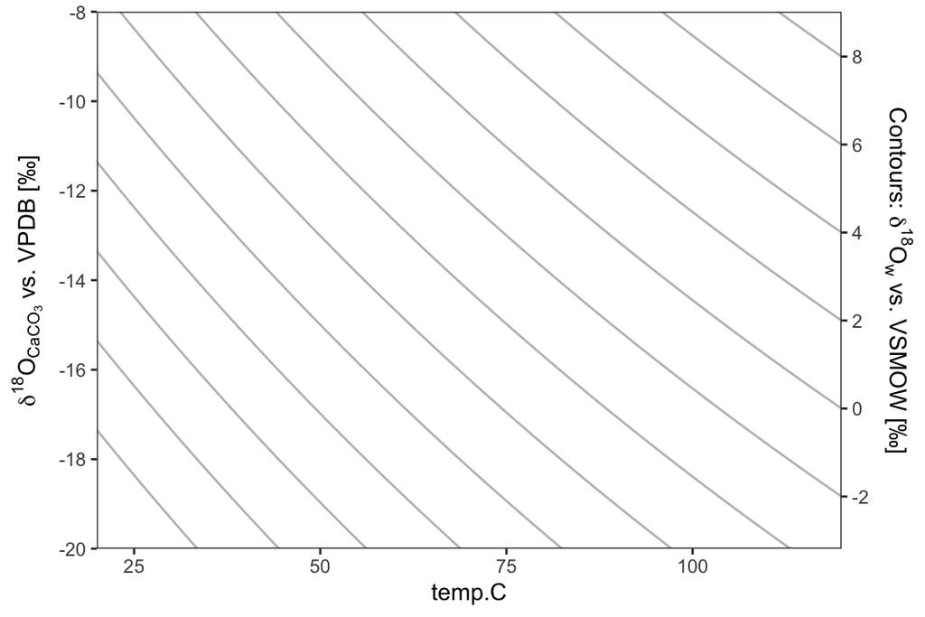

```r
# create a dataframe for the contours
model_df <-
  crossing(
    d_H2O.permil = seq(-16, 16, by = 2), # set the lower and upper bounds of the d18O of water and the step (determines how many steps between the bounds)
    temp.C = seq(10, 120, by = 1) # set the lower and upper bounds of the temperature and the step
  ) |>
  mutate(
    d_CaCO3.permil = d_H2O.permil |> # make column of carbonate d18O from the d18O water permil column using the functions defined above and the temp.C column as inputs (from 10-120 by increases of 1)
      convert_vsmow_to_vpdb() |>
      calculate_d_CaCO3_from_H2O(temp.C)
  )

# plot the contours
plot5 <- model_df |>
  ggplot() +
  aes(x = temp.C, y = d_CaCO3.permil, group = factor(d_H2O.permil)) +
  geom_line(color = "grey", linewidth = 0.5) +
  # make sec axis
  scale_y_continuous(
    # customize y axis
    name = latex2exp::TeX("$\\delta^{18}O_{CaCO_3}$ vs. VPDB [\U2030]"), # rename carbonate d18O with permil symbol
    #labels = function(x) paste0(x, "\U2030"),
    breaks = seq(-20, -6, 2), # set range from -20 to -6 by steps of 2
    sec.axis = sec_axis(
      name = latex2exp::TeX(
        "Contours: $\\delta^{18}O_{w}$ vs. VSMOW [\U2030]" # rename wataer d18O with permil symbol
      ),
      breaks = unique(model_df$d_H2O.permil),
      #labels = function(x) paste0(x, "\U2030"),
      transform = function(y) {
        y |>
          calculate_d_H2O_from_CaCO3(temp.C = max(model_df$temp.C)) |>
          convert_vpdb_to_vsmow()
      }
    )
  ) +
  # limit plot to near y range of data that will be plotted over top
  coord_cartesian(
    ylim = c(-20, -8),
    xlim = c(20, 120),
    expand = FALSE # crop exactly to size
  ) +
  theme_bw() +
  theme(panel.grid = element_blank()) # get rid of grid lines


plot5
```

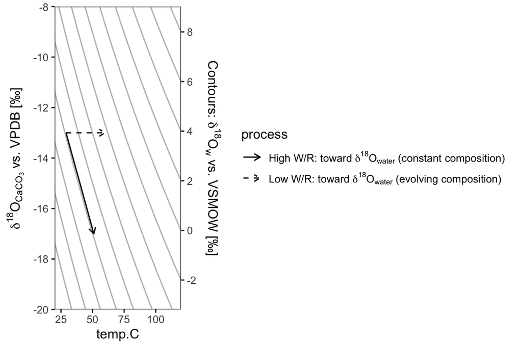

```r
# add arrow
arrows <- tibble(
  process = c("diagenesis1", "diagenesis2"), # naming the processes
  temp_start = 29, # starting temp (x) for both arrows
  delta_start = -13, # starting d18O (y) for both arrows
  temp_end = c(51, 60), # ending temp for high and low w/r alteration trajectories, respectively
  delta_end = c(-17, -13) # ending d18O for high and low w/r alteration trajectories, respectively
)

plot6 <- plot5 +
  geom_segment(
    data = arrows, # add the arrows
    map = aes(
      x = temp_start, # where the arrows start in x (temp) space
      y = delta_start, # where the arrows start in y (d81Ocarb) space
      xend = temp_end, # where the arrows end in x (temp) space
      yend = delta_end, # where the arrows end in y (d81Ocarb) space
      group = NULL, # get rid of grouping inherited from previous aesthetics in plot5
      linetype = process # separate linetype by process (rather than color) so it is a separate legend
    ),
    arrow = arrow(length = unit(0.2, "cm")) # set arrow cap/head length
  ) +
  scale_linetype_manual(
    # set the linetypes according to the diagenesis process
    values = c("diagenesis1" = "solid", "diagenesis2" = "dashed"),
    labels = list(
      latex2exp::TeX(
        # label arrow diagenesis1 with LaTex text with delta symbol, 18 superscript
        "High W/R: toward $\\delta^{18}O_{water}$ (constant composition)"
      ),
      latex2exp::TeX(
        # label arrow diagenesis2 with LaTex text with delta symbol, 18 superscript
        "Low W/R: toward $\\delta^{18}O_{water}$ (evolving composition)"
      )
    )
  )

plot6
```

## 4.5 Final Plot, Add Star and Isotope Data

Figure 2 is modeled after Fetrow et al. (2022) and shows clumped isotope temperatures (°C), $\delta^{18}O_{carbonate}$ (‰ vs. VPDB), and $\delta^{18}O_{w}$ (‰ vs. VSMOW) for four different types of carbonate at the Willow Creek Anticline: a carbonate-cemented coprolite (see Figure 3), limestone (see Figure 4), a rhizolith (see Figure 5), and vein calcite (see Figure 6). On one hand, the rhizolith and the limestones yield mineral formation temperatures that are reasonable Earth surface temperatures for the Late Cretaceous, thereby likely representing unaltered carbonate endmembers. On the other hand, the vein calcite yields a high temperature (~100°C) and therefore likely represents a purely diagenetic endmember. The coprolite shows a wide range in temperatures and $\delta^{18}O_{carbonate}$ values, likely because it is composed of multiple “coprofabrics” (Chin (2007), Plaza Torres (2023)) that likely mineralized under different conditions and possibly at different times (e.g., Hollocher and Hollocher (2012)). These coprofabrics are labeled in the plot and also shown in Figure 3. The tan and white micrite/sediment coprofabrics and the sparry coprofabric display a variety of temperatures and oxygen isotope values that appear to plot along a high W/R ratio (‘fluid-buffered’) diagenetic alteration trajectory, suggesting that individual fabrics were altered to different extents by a fluid with a constant $\delta^{18}O_{w}$ composition. Interestingly, the sparry coprofabric has a similar $\delta^{18}O_{carbonate}$ value to the vein calcite but a different temperature, which suggests that it could represent alteration along a low W/R ratio (‘rock-buffered’) diagenetic trajectory by fluid with an evolving $\delta^{18}O_{w}$ composition.

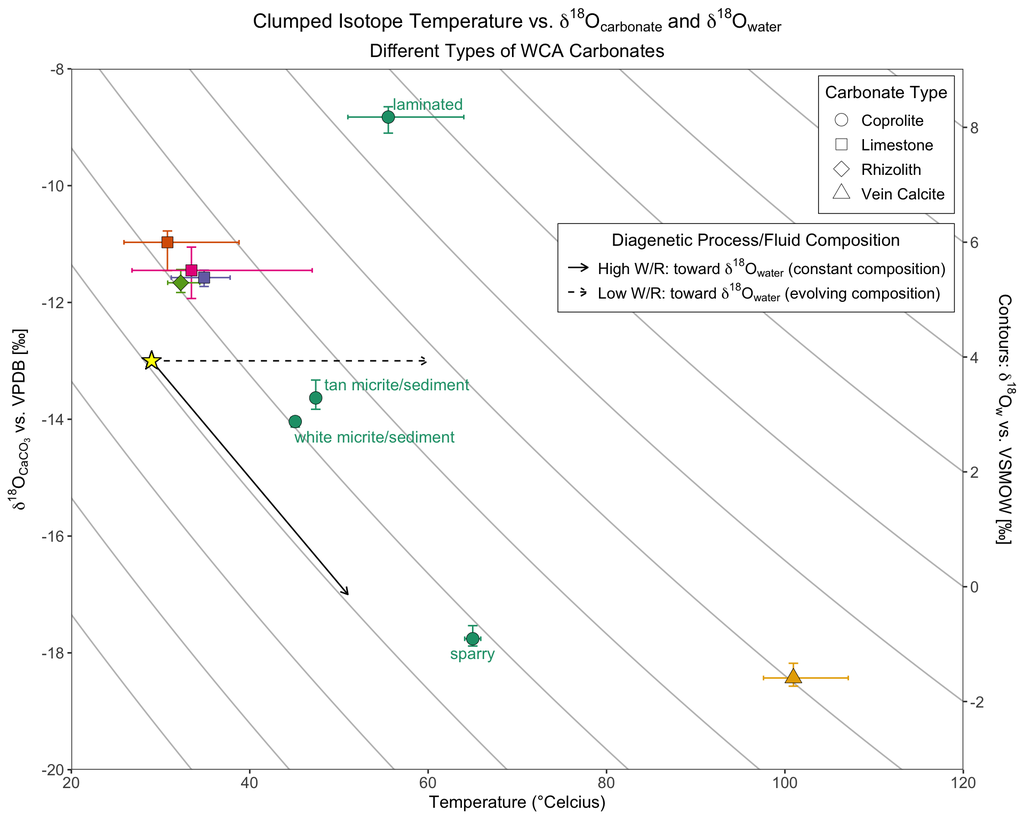

Figure 2: Willow Creek Anticline carbonate clumped isotope $\Delta_{47}$-derived mineral formation temperature in degrees Celcius vs. $\delta^{18}O_{carbonate}$ (measured in ‰ vs. VPDB) with $\delta^{18}O_{w}$ (calculated from $\delta^{18}O_{carbonate}$ and $\Delta_{47}$ temperature, reported in ‰ vs. VSMOW) contour lines, calculated from the fractionation factor (alpha, $\alpha$). Different shapes indicate different types of carbonate, and different colors indicate different specimens of the same type.

```r
plot7 <- plot6 +
  geom_star(
    # add star
    x = 29, # star temp (x)
    y = -13, # star d18O (y)
    size = 4, # size of star
    fill = "yellow", # make it yellow
    color = "black" # with a black outline
  ) +
  # add vertical error bars
  geom_errorbar(
    data = Clumped, # set df
    inherit.aes = FALSE, # false inherit.aes so it doesn't inherit aesthetics from plot5
    aes(
      ymin = min_d18O, # lower extent of error bars
      ymax = max_d18O, # upper extent of error bars
      color = Specimen, # color by specimen
      group = NULL, # get rid of grouping aesthetic just in case (inherited from plot5) bc otherwise it doesn't work
      x = mean_ICDES # explicitly set x for error bars
    )
  ) +
  # add horizontal error bars
  geom_errorbar(
    data = Clumped,
    inherit.aes = FALSE, # false inherit.aes so it doesn't inherit aesthetics from plot5
    aes(
      xmin = min_ICDES, # lower extent of error bars
      xmax = max_ICDES, # upper extent of error bars
      color = Specimen, # color by specimen
      group = NULL, # get rid of grouping aesthetic inherited from plot5 bc otherwise it doesn't work
      y = mean_d18O # explicitly set y for error bars
    )
  ) +
  geom_point(
    # add clumped isotope data
    data = Clumped, # df to use
    inherit.aes = FALSE, # remove inherited aesthetics
    aes(
      x = mean_ICDES, # x value of point as temperature
      y = mean_d18O, # y value of point from d18O carbonate
      shape = Type, # shape by carbonate type
      fill = Specimen, # fill by specimen (same as error bars)
      group = NULL # ungroup so it doesn't inherit from plot5 and throw an error
    ),
    color = "black", # outline in black
    size = 4, # make points a little bigger
    stroke = 0.25 # smaller/thinner black outline
  ) +
  scale_color_brewer(palette = "Dark2") + # set color palette for error bars
  scale_fill_brewer(palette = "Dark2") + # set color palette for points to be the same as error bars
  scale_shape_manual(values = c(21, 22, 23, 24, 25)) + # set shapes to be hollow (with black as stroke/outline color and fill as point fill)
  labs(
    # add titles/labels for plot + legend
    title = latex2exp::TeX(
      "Clumped Isotope Temperature vs. $\\delta^{18}O_{carbonate}$ and $delta^{18}O_{water}$"
    ),
    subtitle = "Different Types of WCA Carbonates",
    x = "Temperature (°Celcius)",
    linetype = "Diagenetic Process/Fluid Composition",
    shape = "Carbonate Type"
  ) + # relabel x axis and arrow legend title
  guides(
    # get rid of fill and color legend since specimen is not as important as type
    fill = "none",
    color = "none",
    shape = guide_legend(order = 1), # reorder the legend entries so shape comes first
    linetype = guide_legend(order = 2) # and linetype comes second (below)
  ) +
  annotate(
    # add labels to plot to label the different types of "coprofabrics" (circular coprolite points, see figure 3 (coprolite pictures with outlines/labels) for what they look like): sparry
    "text", # set text annotation
    x = 65, # set x position
    y = -18, # set y position
    color = "#1B9E77", # set color to be same as point color
    size = 4, # set small size
    label = "sparry" # set label text
  ) +
  annotate(
    # add labels to plot to label the different types of "coprofabrics" (circular coprolite points, see figure 3 (coprolite pictures with outlines/labels) for what they look like): laminated
    "text",
    x = 60,
    y = -8.6,
    color = "#1B9E77",
    size = 4,
    label = "laminated"
  ) +
  annotate(
    # add labels to plot to label the different types of "coprofabrics" (circular coprolite points, see figure 3 (coprolite pictures with outlines/labels) for what they look like): white micrite/sediment
    "text",
    x = 54,
    y = -14.3,
    color = "#1B9E77",
    size = 4,
    label = "white micrite/sediment"
  ) +
  annotate(
    # add labels to plot to label the different types of "coprofabrics" (circular coprolite points, see figure 3 (coprolite pictures with outlines/labels) for what they look like): tan micrite/sediment
    "text",
    x = 56.5,
    y = -13.4,
    color = "#1B9E77",
    size = 4,
    label = "tan micrite/sediment"
  ) +
  # customize theme
  scale_x_continuous(breaks = seq(20, 140, 20)) +
  theme(
    plot.title = element_text(hjust = 0.5, face = "bold", size = 14), # center, bold, size plot title
    plot.subtitle = element_text(hjust = 0.5, size = 13), # center, size plot subtitle
    axis.title = element_text(size = 12), # set axis title size
    axis.text = element_text(size = 11), # set axis text size
    axis.title.y.left = element_text(size = 12), # set left y axis text size
    axis.title.y.right = element_text(size = 12), # set right y axis text size
    legend.background = element_rect(
      # give the plot a thin black border
      color = "black",
      fill = NULL,
      linewidth = 0.25
    ),
    legend.title = element_text(hjust = 0.5, size = 12), # size legend title text
    legend.text = element_text(size = 11), # size legend entry text
    legend.position = "inside", # put the legend inside the plot
    legend.justification = c("right", "top"), # right justify legend
    legend.position.inside = c(.99, .99), # set position relative to top right
    legend.box.just = "right", # right justify legend boxes
    legend.spacing.y = unit(0.25, "cm") # set smaller margin between legends
  )

plot7
```

# 5 Pictures

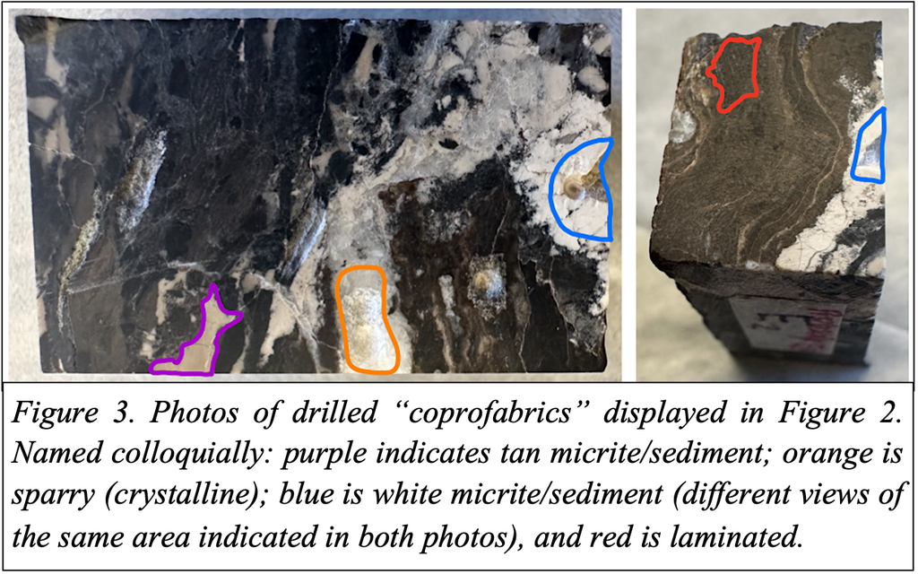

```r
# load magick for images
library(magick)
# read images in from images folder
coprofabrics <- image_read("images/coprofabrics.png")

coprofabrics
```

[figure not shown]

```r
limestones <- image_read("images/limestones.png")

limestones
```

[figure not shown]

```r
rhizolith <- image_read("images/rhizolith.png")

rhizolith
```

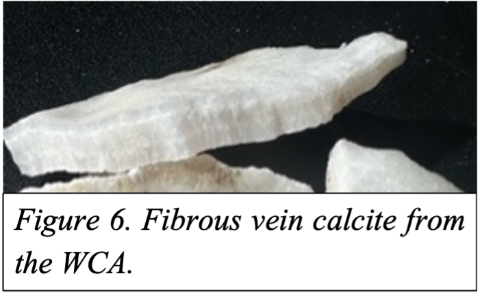

```r
vein_calcite <- image_read("images/vein_calcite.png")

vein_calcite
```

# 6 Discussion

•Mineral formation temperatures of limestones and carbonate-infilled rhizolith represent reasonable Late Cretaceous Earth surface temperatures (~28-38°C), representing the unaltered endmembers.

•Vein calcite yields a mineral formation temperature consistent with high-temperature diagenetic fluid (~100°C), representing our diagenetic endmember.

•Coprolite carbonate mineral formation temperatures vary with the type of “coprofabric” analyzed (~44-66°C) and represent diagenetic alteration trajectories.

•Overall, the stable isotope compositions of limestones and a rhizolith are consistent with Earth surface conditions; that of vein calcite is consistent with diagenetic fluid; and those of different coprolite “coprofabrics” consistent with different degrees of diagenetic recrystallization.

# 7 References

Chin, Karen. 2007. “The Paleobiological Implications Of Herbivorous Dinosaur Coprolites From The Upper Cretaceous Two Medicine Formation Of Montana: Why Eat Wood?” *PALAIOS* 22 (5): 554–66. https://doi.org/10.2110/palo.2006.p06-087r.

Cobban, Erdmann, W. A., and E. K. Maughan. 1959a. *Colorado Group on Sweetgrass Arch, Montana, in Billings Geological Society Guidebook, 10th Annual Field Conference, 1959*.

Cobban, Erdmann, W. A., and E. K. Maughan. 1959b. *Revision of Colorado Group on Sweetgrass Arch, Montana*. 1959b.

Cobban, Erdmann, W. A., and E. K. Maughan. 1976. *Type Sections and Stratigraphy of the Members of the Blackleaf and Marias River Formations (Cretaceous) of the Sweetgrass Arch, Montana*. https://pubs.usgs.gov/pp/0974/.

Cobban, W. A. 1955. *Cretaceous Rocks of Northwestern Montana, in Billings Geological Society Guidebook, 6th Annual Field Conference, 1955*.

Deiss, C. F. 1939. *Cambrian Stratigraphy and Trilobites of Northwestern Montana*.

Earhart, Grimes, R. L., and L. Y. Marks. 1976. *1977. Mineral Resources of Proposed Additions to the Scapegoat Wilderness, Powell and Lewis and Clark Counties, Montana*. https://pubs.er.usgs.gov/publication/b1430.

Fetrow, A. C., K. E. Snell, R. V. Di Fiori, S. P. Long, and J. W. Bonde. 2022. “How Hot Is Too Hot? Disentangling Mid-Cretaceous Hothouse Paleoclimate From Diagenesis.” *Paleoceanography and Paleoclimatology* 37 (12): e2022PA004517. https://doi.org/10.1029/2022PA004517.

Harris, III, F. G. 1963. “Geology of the Dry Creek Area, Lewis and Clark County, Montana.” PhD thesis.

Harrison, Reynolds, J. E., and E. C. Pattee. 1969. *Mineral Resources of the Mission Mountains Primitive Area, Missoula and Lake Counties, Montana*. https://pubs.usgs.gov/bul/1261d/.

Harrison, unpublished mapping. n.d. *Harrison, Unpublished Mapping*.

Hernandez, Micah A, and Logan A Owen. 2023. *GIS Data for Geologic and Structure Map of the Choteau 1 x 2 Degree Quadrangle, Western Montana*. U.S. Geological Survey. https://doi.org/10.5066/P93PTFDV.

Hollocher, Kurt, and Thomas C. Hollocher. 2012. “Early Processes in the Fossilization of Terrestrial Feces to Coprolites, and Microstructure Preservation.” In *Vertebrate Coprolites: Bulletin 57*, edited by A. P. Hunt, J. Milàn, S Lucas, and J Spielmann, vol. 57. New Mexico Museum of Natural History; Science.

Johns, 1970. 1970. *Geology and Mineral Deposits of Lincoln and Flathead Counties, Montana*. http://www.mbmg.mtech.edu/mbmgcat/public/ListCitation.asp?pub_id=10080&.

Lyons, J. B. 1944. *Igneous Rocks of the Northern Big Belt Range, Montana*. https://pubs.geoscienceworld.org/gsa/gsabulletin/article/55/4/445/4037/igneous-rocks-of-the-northern-big-belt-range.

Mehnert, H. H., and R. G. Schmidt. 1971. *Geological Survey Research 1971 [1972]*. https://pubs.er.usgs.gov/publication/pp750A.

Mudge, Earhart, M. R., and J. E. Harrison. 1982. *Geologic and Structure Map of the Choteau 1 x 2 Degree Quadrangle, Western Montana*. https://doi.org/10.3133/i1300.

Mudge, Earhart, M. R., and W. L. Rice. 1974. *Mineral Resources of the Scapegoat Wilderness, Powell and Lewis and Clark Counties, Montana*. https://pubs.usgs.gov/bul/1385b/.

Mudge, Earhart, M. R., and J. T. Silkwood. 2001. *Geologic and Structure Map of the Choteau 1 x 2 Degree Quadrangle, Western Montana*. https://pubs.er.usgs.gov/publication/i1300.

Mudge, M. R. 1972. *Pre-Quaternary Rocks in the Sun River Canyon Area, Northwestern Montana*. https://pubs.er.usgs.gov/publication/pp663A.

Mudge, M. R., and R. L. Earhart. 1978. *Geology of the Bob Marshall Wilderness and Study Area, Chapter a, in Mineral Resources of the Bob Marshall Wilderness and Study Area, Lewis and Clark, Teton, Pondera, Flathead, Lake, Missoula, and Powell Counties, Montana*. https://pubs.er.usgs.gov/publication/ofr78295.

Mudge, M. R., and R. A. Sheppard. 1968. *Mudge and Sheppard, 1968*. https://pubs.er.usgs.gov/publication/pp600D.

Mudge, Sando, M. R., and Jr. Dutro J. T. 1962. *Mississippian Rocks of Sun River Canyon Area, Sawtooth Range, Montana*.

Mudge, unpublished mapping. n.d. *Mudge, Unpublished Mapping*.

Mudge, and unpublished mapping Earhart. n.d. *Mudge and Earhart, Unpublished Mapping*.

Neuendorf, Mehl Jr., K. K. E., and J. A. Jackson. 2011. *Glossary of Geology (Fifth Edition)*.

O’Connor, M. P. 1967. “Stratigraphy and Petrology Across the Precambrian Piegan Group - Missoula Group Boundary, Southern Mission and Swan Ranges, Montana.” PhD thesis.

Plaza Torres, Stephanie Marie. 2023. “New Applications of Carbon Stable Isotope Geochemistry to Coprolites and Plant Fossils.” Master’s thesis, University of Colorado at Boulder. https://colorado.idm.oclc.org/login?url=https://www.proquest.com/dissertations-theses/new-applications-carbon-stable-isotope/docview/2866259546/se-2?accountid=14503.

Program, U. S. Geological Survey National Cooperative Geologic Mapping. 2020. *GeMS (Geologic Map Schema) - a Standard Format for the Digital Publication of Geologic Maps*. https://doi.org/10.3133/tm11B10.

R Core Team. 2022. *R: A Language and Environment for Statistical Computing*. R Foundation for Statistical Computing. https://www.R-project.org/.

Schmidt, R. G. 1972a. *Geologic Map of the Wolf Creek Quadrangle, Lewis and Clark Counties, Montana*. https://ngmdb.usgs.gov/Prodesc/proddesc_2273.htm.

Schmidt, R. G. 1972b. *Geologic Map of the Coburn Mountain Quadrangle, Lewis and Clark Counties, Montana*. https://ngmdb.usgs.gov/Prodesc/proddesc_2274.htm.

Schmidt, R. G. 1972c. *Geologic Map of the Comb Rock Quadrangle, Lewis and Clark Counties, Montana*. https://ngmdb.usgs.gov/Prodesc/proddesc_2275.htm.

Schmidt, R. G. 1978. *Rocks and Mineral Resources of the Wolf Creek Area, Lewis and Clark and Cascade Counties, Montana*. https://pubs.er.usgs.gov/publication/b1441.

Schmidt, R. G., and Jr. Strong C. P. 1972. *Geologic Map of the Roberts Mountain Quadrangle, Lewis and Clark Counties, Montana*. https://ngmdb.usgs.gov/Prodesc/proddesc_2276.htm.

Sommers, D. A. 1966. “Stratigraphy and Structure of a Portion of the Bob Marshall Wilderness Area, Northwestern Montana.” PhD thesis.

Viele, G. W. 1960. “The Geology of the Flat Creek Area, Lewis and Clark Counties, Montana.” PhD thesis.

Viele, G. W., and F. G. Harris. 1965. *Montana Group Stratigraphy, Lewis and Clark County, Montana*.

Whipple, and unpublished mapping others. n.d. *Whipple and Others, Unpublished Mapping*.

Wickham, Hadley, Mara Averick, Jennifer Bryan, et al. 2019. “Welcome to the tidyverse.” *Journal of Open Source Software* 4 (43): 1686. https://doi.org/10.21105/joss.01686.